# Shark Tank

Michael Cao

2023-04-04

Summary of NA entries in each column (original data)

```r
dat <- read.csv("Shark Tank US dataset.csv")
dat.copy <- dat
dim(dat)
```

```
## [1] 1097   50
```

```r
colSums(is.na(dat))
```

```
##                      Season.Number                       Season.Start
##                                  0                                  0
##                         Season.End                     Episode.Number
##                                  0                                  0
##                       Pitch.Number                  Original.Air.Date
##                                  0                                  0
##                       Startup.Name                           Industry
##                                  0                                  0
##               Business.Description                    Pitchers.Gender
##                                  0                                  0
##                      Pitchers.City                     Pitchers.State
##                                  0                                  0
##               Pitchers.Average.Age                 Entrepreneur.Names
##                                  0                                  0
##                    Company.Website             Multiple.Entrepreneurs
##                                  0                                478
##                      US.Viewership                Original.Ask.Amount
##                                215                                  0
##            Original.Offered.Equity                Valuation.Requested
##                                  0                                  0
##                           Got.Deal                  Total.Deal.Amount
##                                  0                                454
##                  Total.Deal.Equity                     Deal.Valuation
##                                454                                454
##           Number.of.sharks.in.deal        Investment.Amount.Per.Shark
##                                454                                454
##                   Equity.Per.Shark                       Royalty.Deal
##                                454                               1042
##                               Loan Barbara.Corcoran.Investment.Amount
##                               1055                                992
## Barbara.Corcoran.Investment.Equity       Mark.Cuban.Investment.Amount
##                                992                                902
##       Mark.Cuban.Investment.Equity     Lori.Greiner.Investment.Amount
##                                902                                932
##     Lori.Greiner.Investment.Equity  Robert.Herjavec.Investment.Amount
##                                932                                992
##  Robert.Herjavec.Investment.Equity     Daymond.John.Investment.Amount
##                                992                                998
##     Daymond.John.Investment.Equity    Kevin.O.Leary.Investment.Amount
##                                998                                996
##    Kevin.O.Leary.Investment.Equity            Guest.Investment.Amount
##                                996                               1017
##            Guest.Investment.Equity                         Guest.Name
##                               1017                                  0
##           Barbara.Corcoran.Present                 Mark.Cuban.Present
##                                202                                201
##               Lori.Greiner.Present            Robert.Herjavec.Present
##                                201                                201
##               Daymond.John.Present              Kevin.O.Leary.Present
##                                202                                202
```

Inspect each column

```r
table(dat$Season.Number) #good
```

```
##
##   1   2   3   4   5   6   7   8   9  10  11  12  13  14
##  64  36  60 103 116 116 116  96  96  92  96  40  40  26
```

```r
table(dat$Episode.Number) #good
```

```
##
##  1  2  3  4  5  6  7  8  9 10 11 12 13 14 15 16 17 18 19 20 21 22 23 24 25 26
## 57 57 56 57 57 57 55 51 52 48 41 40 40 41 36 32 32 32 32 32 32 32 32 28 16 16
## 27 28 29
## 12 12 12
```

```r
table(dat$Season.Start) #good
```

```
##
## 01-Oct-17 07-Oct-18 08-Oct-21 09-Aug-09 14-Sep-12 16-Oct-20 20-Jan-12 20-Mar-11
##        96        92        40        64       103        40        60        36
## 20-Sep-13 23-Sep-16 23-Sep-22 25-Sep-15 26-Sep-14 29-Sep-19
##       116        96        26       116       116        96
```

```r
which(dat$Startup.Name=='') #good
```

```
## integer(0)
```

```r
table(dat$Industry) #good
```

```
##
##              Automotive       Business Services      Children/Education
##                      14                      30                     108
##             Electronics          Fashion/Beauty Fitness/Sports/Outdoors
##                      14                     191                     106
##       Food and Beverage         Green/CleanTech         Health/Wellness
##                     229                      11                      51
##          Lifestyle/Home     Media/Entertainment            Pet Products
##                     195                      24                      44
##           Software/Tech                  Travel         Uncertain/Other
##                      60                      11                       9
```

```r
sum(dat$Business.Description=='') #good
```

```
## [1] 0
```

```r
sum(dat$Entrepreneur.Names=='') # missing names - but okay
```

```
## [1] 549
```

```r
table(dat$Original.Ask.Amount) #good
```

```
##
##   10000   20000   25000   30000   35000   40000   45000   48000   50000   54000
##       2       1       7      10       5       9       2       1      81       1
##   55000   57000   60000   65000   70000   75000   80000   85000   86000   90000
##       6       1      11       1       1      43      16       5       1      12
##   95000  100000  105000  110000  115000  120000  125000  130000  140000  150000
##       1     140       2       3       1       8      28       1       1     113
##  155000  160000  175000  180000  185000  200000  225000  250000  258000  260000
##       1       4       7       3       1     115       6      91       1       1
##  270000  275000  285000  300000  325000  350000  360000  375000  400000  425000
##       1       3       1      77       3      19       1       6      39       1
##  450000  460000  499000  500000  540000  550000  600000  625000  640000  650000
##       3       2       1     109       1       2      15       1       1       1
##  700000  725000  750000  800000  900000 1000000 1200000 1250000 1400000 1500000
##       4       1      11       5       1      20       1       1       1       6
## 2000000 2500000 3000000 5000000
##       9       2       2       2
```

```r
table(dat$Original.Offered.Equity) #good
```

```
##
##  1.5    2  2.5    3  3.1  3.5    4  4.5    5    6  6.3    7  7.5  7.6    8    9
##    1    4   10    7    1    3    9    1  129    7    1   14    8    1   26    1
##   10   11   12 12.5   13 13.5   14   15   16   17 17.5   18   20   22   25   26
##  346    1   13    7    2    1    2  142    3    1    2    4  207    1   69    1
##   29   30   33 33.3   34   35   40   45   50   51   70  100
##    1   30   10    1    1    5   12    1    5    4    1    1
```

```r
table(dat$Valuation.Requested) #good
```

```
##
##    40000    49020    50000    85714   100000   106061   120000   121212
##        1        1        1        1        9        1        2        1
##   125000   133333   140000   150000   156863   160000   166667   175000
##        3        1        1        3        1        1        4        1
##   176471   190000   192000   196078   200000   207692   212500   220000
##        1        1        1        1       20        1        1        2
##   225000   233333   242424   250000   260000   266667   275000   285714
##        1        1        1       25        1        3        2        1
##   300000   300300   303030   325000   333333   350000   360000   375000
##       13        1        1        1       16        2        1       12
##   384615   400000   416667   425000   428571   430000   450000   454545
##        1       20        2        1        2        1        2        1
##   458333   480000   500000   525000   533333   571429   600000   625000
##        1        1       78        1        3        1       16       16
```

[output cut: 28 more lines]

```r
table(dat$Got.Deal) #good
```

```
##
##   0   1
## 454 643
```

```r
table(dat$Season.End) #need to fix
```

```
##
##           05-Feb-10 12-May-17 12-May-19 13-May-11 15-May-15 15-May-20 16-May-14
##        26        64        96        92        36       116        96       116
## 17-May-13 18-May-12 20-May-16 20-May-22 21-May-21 25-Feb-18
##       103        60       116        40        40        96
```

```r
sum(dat$Original.Air.Date == '') #need to fix
```

```
## [1] 191
```

```r
table(dat$Pitchers.Gender) #need to fix
```

```
##
##                Female       Male Mixed Team
##          6        272        623        196
```

```r
sum(dat$Pitchers.City=='') #599 missing cities - hard to fix
```

```
## [1] 599
```

```r
sum(dat$Pitchers.State=='') #358 missing states - hard to fix
```

```
## [1] 358
```

```r
table(dat$Pitchers.Average.Age) #984 missing ages - to be removed
```

```
##
##           Kid Middle    Old  Young
##    984      1     98      1     13
```

```r
table(dat$Company.Website=='') #inaccurate column - to be removed
```

```
##
## FALSE  TRUE
##   492   605
```

```r
sum(is.na(dat$Multiple.Entrepreneurs)) #need to convert the 478 NAs
```

```
## [1] 478
```

```r
sum(is.na(dat$US.Viewership)) #useless column - to be removed
```

```
## [1] 215
```

```r
# take special note of the following columns (loan/royalty deals)
range(dat$Total.Deal.Amount, na.rm=T) #convert NA to 0 or not??
```

```
## [1]       0 5000000
```

```r
which(dat$Total.Deal.Amount==0) #need to fix row 641
```

```
## [1] 641
```

```r
range(dat$Total.Deal.Equity, na.rm=T)
```

```
## [1]   0 100
```

```r
which(dat$Total.Deal.Equity==0)
```

```
## [1] 208 244 313 400 641 884 998
```

```r
range(dat$Deal.Valuation, na.rm=T)
```

```
## [1]        0 36000000
```

```r
which(dat$Deal.Valuation==0)
```

```
## [1]  208  244  313  400  641  884  998 1065
```

```r
range(dat$Investment.Amount.Per.Shark, na.rm=T)
```

```
## [1] 0e+00 5e+06
```

```r
which(dat$Investment.Amount.Per.Shark==0) #row 641 again
```

```
## [1] 641
```

```r
table(dat$Royalty.Deal) #convert all NAs to 0
```

```
##
##  1
## 55
```

```r
table(dat$Loan) #need to fix
```

```
##
##      1  75000 200000 250000 700000
##     37      1      1      2      1
```

```r
#lastly, we need to fix/ fill NAs for the individual shark columns
sum(is.na(dat$Barbara.Corcoran.Present))
```

```
## [1] 202
```

```r
table(dat$Barbara.Corcoran.Present)
```

```
##
##   0   1
## 391 504
```

```r
table(dat$Barbara.Corcoran.Investment.Amount)
```

```
##
##   12500   20000   25000   35000   37500   50000   52500   55000   60000   62500
##       1       1       1       1       1      27       1       1       1       1
##   70000   75000   80000   90000  100000  112500  125000  150000  175000  180000
##       1       7       1       1      16       1       2       7       1       2
##  200000  230000  250000  300000  350000  400000  600000 1000000
##       9       1       7       7       2       2       1       1
```

```r
table(dat$Barbara.Corcoran.Investment.Equity)
```

```
##
##    5  7.5    8   10 12.5   15   16   18   20   21 22.5   25   30   33 33.3   35
##    5    1    1   13    5    9    1    2   17    1    1   17    6    3    2    2
##   38   40   45   49   50   51   55
##    1    7    1    1    7    1    1
```

Remove Pitchers.Average.Age, Company.Website, US.Viewership columns

```r
dim(dat)
```

```
## [1] 1097   50
```

```r
dat <- dat[, !names(dat) %in%
             c("Pitchers.Average.Age", "Company.Website", "US.Viewership")]
dim(dat)
```

```
## [1] 1097   47
```

Fill in missing season dates and reformatting

```r
table(dat$Season.Start)
```

```
##
## 01-Oct-17 07-Oct-18 08-Oct-21 09-Aug-09 14-Sep-12 16-Oct-20 20-Jan-12 20-Mar-11
##        96        92        40        64       103        40        60        36
## 20-Sep-13 23-Sep-16 23-Sep-22 25-Sep-15 26-Sep-14 29-Sep-19
##       116        96        26       116       116        96
```

```r
dat$Season.Start <- format(as.Date(dat$Season.Start, format = '%d-%b-%y'), '%m/%d/%Y')
table(dat$Season.Start)
```

```
##
## 01/20/2012 03/20/2011 08/09/2009 09/14/2012 09/20/2013 09/23/2016 09/23/2022
##         60         36         64        103        116         96         26
## 09/25/2015 09/26/2014 09/29/2019 10/01/2017 10/07/2018 10/08/2021 10/16/2020
##        116        116         96         96         92         40         40
```

```r
table(dat$Season.End)
```

```
##
##           05-Feb-10 12-May-17 12-May-19 13-May-11 15-May-15 15-May-20 16-May-14
##        26        64        96        92        36       116        96       116
## 17-May-13 18-May-12 20-May-16 20-May-22 21-May-21 25-Feb-18
##       103        60       116        40        40        96
```

```r
which(dat$Season.End=='')
```

```
##  [1] 1072 1073 1074 1075 1076 1077 1078 1079 1080 1081 1082 1083 1084 1085 1086
## [16] 1087 1088 1089 1090 1091 1092 1093 1094 1095 1096 1097
```

```r
dat$Season.End[which(dat$Season.End=='')] <- '20-Apr-23'
dat$Season.End <- format(as.Date(dat$Season.End, format = '%d-%b-%y'), '%m/%d/%Y')
table(dat$Season.End)
```

```
##
## 02/05/2010 02/25/2018 04/20/2023 05/12/2017 05/12/2019 05/13/2011 05/15/2015
##         64         96         26         96         92         36        116
## 05/15/2020 05/16/2014 05/17/2013 05/18/2012 05/20/2016 05/20/2022 05/21/2021
##         96        116        103         60        116         40         40
```

Fix the episode air date column (Manually)

```r
sum(dat$Original.Air.Date == '')
```

```
## [1] 191
```

```r
rows_with_na <- which(dat$Original.Air.Date=='')
eps_with_na <- unique(dat[rows_with_na, c('Season.Number', 'Episode.Number')])
eps_with_na
```

```
##      Season.Number Episode.Number
## 772              9             17
## 776              9             18
## 780              9             19
## 784              9             20
## 788              9             21
## 792              9             22
## 796              9             23
## 808             10              2
## 812             10              3
## 816             10              4
## 820             10              5
## 824             10              6
## 828             10              7
## 836             10              9
```

[output cut: 34 more lines]

```r
dat[dat$Season.Number==9 & dat$Episode.Number==17, 'Original.Air.Date'] <- '14-Jan-18'
dat[dat$Season.Number==9 & dat$Episode.Number==18, 'Original.Air.Date'] <- '21-Jan-18'
dat[dat$Season.Number==9 & dat$Episode.Number==19, 'Original.Air.Date'] <- '28-Jan-18'
dat[dat$Season.Number==9 & dat$Episode.Number==20, 'Original.Air.Date'] <- '28-Jan-18'
dat[dat$Season.Number==9 & dat$Episode.Number==21, 'Original.Air.Date'] <- '11-Feb-18'
dat[dat$Season.Number==9 & dat$Episode.Number==22, 'Original.Air.Date'] <- '18-Feb-18'
dat[dat$Season.Number==9 & dat$Episode.Number==23, 'Original.Air.Date'] <- '25-Feb-18'

dat[dat$Season.Number==10 & dat$Episode.Number==2, 'Original.Air.Date'] <- '14-Oct-18'
dat[dat$Season.Number==10 & dat$Episode.Number==3, 'Original.Air.Date'] <- '21-Oct-18'
dat[dat$Season.Number==10 & dat$Episode.Number==4, 'Original.Air.Date'] <- '28-Oct-18'
dat[dat$Season.Number==10 & dat$Episode.Number==5, 'Original.Air.Date'] <- '18-Nov-18'
dat[dat$Season.Number==10 & dat$Episode.Number==6, 'Original.Air.Date'] <- '25-Nov-18'
dat[dat$Season.Number==10 & dat$Episode.Number==7, 'Original.Air.Date'] <- '02-Dec-18'
dat[dat$Season.Number==10 & dat$Episode.Number==9, 'Original.Air.Date'] <- '06-Jan-19'
dat[dat$Season.Number==10 & dat$Episode.Number==12, 'Original.Air.Date'] <- '27-Jan-19'
dat[dat$Season.Number==10 & dat$Episode.Number==13, 'Original.Air.Date'] <- '27-Jan-19'
dat[dat$Season.Number==10 & dat$Episode.Number==14, 'Original.Air.Date'] <- '03-Mar-19'
dat[dat$Season.Number==10 & dat$Episode.Number==15, 'Original.Air.Date'] <- '10-Mar-19'
dat[dat$Season.Number==10 & dat$Episode.Number==16, 'Original.Air.Date'] <- '17-Mar-19'
dat[dat$Season.Number==10 & dat$Episode.Number==17, 'Original.Air.Date'] <- '24-Mar-19'
dat[dat$Season.Number==10 & dat$Episode.Number==18, 'Original.Air.Date'] <- '07-Apr-19'
dat[dat$Season.Number==10 & dat$Episode.Number==19, 'Original.Air.Date'] <- '14-Apr-19'
dat[dat$Season.Number==10 & dat$Episode.Number==20, 'Original.Air.Date'] <- '21-Apr-19'
dat[dat$Season.Number==10 & dat$Episode.Number==21, 'Original.Air.Date'] <- '28-Apr-19'
dat[dat$Season.Number==10 & dat$Episode.Number==22, 'Original.Air.Date'] <- '05-May-19'

dat[dat$Season.Number==11 & dat$Episode.Number==2, 'Original.Air.Date'] <- '06-Oct-19'
dat[dat$Season.Number==11 & dat$Episode.Number==4, 'Original.Air.Date'] <- '20-Oct-19'
dat[dat$Season.Number==11 & dat$Episode.Number==5, 'Original.Air.Date'] <- '27-Oct-19'
dat[dat$Season.Number==11 & dat$Episode.Number==6, 'Original.Air.Date'] <- '03-Nov-19'
dat[dat$Season.Number==11 & dat$Episode.Number==7, 'Original.Air.Date'] <- '10-Nov-19'
dat[dat$Season.Number==11 & dat$Episode.Number==8, 'Original.Air.Date'] <- '17-Nov-19'
dat[dat$Season.Number==11 & dat$Episode.Number==9, 'Original.Air.Date'] <- '01-Dec-19'
dat[dat$Season.Number==11 & dat$Episode.Number==10, 'Original.Air.Date'] <- '05-Jan-20'
dat[dat$Season.Number==11 & dat$Episode.Number==11, 'Original.Air.Date'] <- '12-Jan-20'
dat[dat$Season.Number==11 & dat$Episode.Number==12, 'Original.Air.Date'] <- '19-Jan-20'
dat[dat$Season.Number==11 & dat$Episode.Number==13, 'Original.Air.Date'] <- '28-Feb-20'
dat[dat$Season.Number==11 & dat$Episode.Number==14, 'Original.Air.Date'] <- '06-Mar-20'
dat[dat$Season.Number==11 & dat$Episode.Number==15, 'Original.Air.Date'] <- '13-Mar-20'
dat[dat$Season.Number==11 & dat$Episode.Number==16, 'Original.Air.Date'] <- '20-Mar-20'
dat[dat$Season.Number==11 & dat$Episode.Number==17, 'Original.Air.Date'] <- '27-Mar-20'
dat[dat$Season.Number==11 & dat$Episode.Number==18, 'Original.Air.Date'] <- '03-Apr-20'
dat[dat$Season.Number==11 & dat$Episode.Number==19, 'Original.Air.Date'] <- '10-Apr-20'
dat[dat$Season.Number==11 & dat$Episode.Number==21, 'Original.Air.Date'] <- '06-May-20'
dat[dat$Season.Number==11 & dat$Episode.Number==22, 'Original.Air.Date'] <- '08-May-20'
dat[dat$Season.Number==11 & dat$Episode.Number==23, 'Original.Air.Date'] <- '13-May-20'

dat[dat$Season.Number==14 & dat$Episode.Number==4, 'Original.Air.Date'] <- '14-Oct-22'
dat[dat$Season.Number==14 & dat$Episode.Number==5, 'Original.Air.Date'] <- '21-Oct-22'
dat[dat$Season.Number==14 & dat$Episode.Number==6, 'Original.Air.Date'] <- '11-Nov-22'
dat[dat$Season.Number==14 & dat$Episode.Number==7, 'Original.Air.Date'] <- '18-Nov-22'

dat$Original.Air.Date <- format(as.Date(dat$Original.Air.Date,
                                        format = '%d-%b-%y'), '%m/%d/%Y')
sum(dat$Original.Air.Date == '')
```

```
## [1] 0
```

Fix the Gender column

```r
table(dat$Pitchers.Gender)
```

```
##
##                Female       Male Mixed Team
##          6        272        623        196
```

```r
rows <- which(dat$Pitchers.Gender=='')
dat[rows, 'Entrepreneur.Names']
```

```
## [1] "Wylie Robinson"                "Juan Salinas"
## [3] "Sobhan Kanaee and Kanz Kayfan" "Jordan Long and Liz Charm"
## [5] "Dwayne Walker and Tim Samuel"  "Tommy Holl"
```

```r
dat$Pitchers.Gender[rows] <- c('Male', 'Male', 'Male', 'Mixed Team', 'Male', 'Male')
dat$Pitchers.Gender[dat$Pitchers.Gender=='Mixed Team'] <- 'Mixed'
table(dat$Pitchers.Gender)
```

```
##
## Female   Male  Mixed
##    272    628    197
```

Re-numbering Pitch.Number

```r
range(dat$Pitch.Number)
```

```
## [1]    1 1098
```

```r
tail(dat$Pitch.Number)
```

```
## [1] 1093 1094 1095 1096 1097 1098
```

```r
which(!(1:1097 %in% dat$Pitch.Number))
```

```
## [1] 1083
```

```r
dat$Pitch.Number <- 1:1097
```

Convert NAs in Multiple.Entrepreneurs

```r
sum(is.na(dat$Multiple.Entrepreneurs))
```

```
## [1] 478
```

```r
table(dat$Multiple.Entrepreneurs)
```

```
##
##   0   1
## 360 259
```

```r
dat$Multiple.Entrepreneurs[is.na(dat$Multiple.Entrepreneurs)] <- 0
table(dat$Multiple.Entrepreneurs)
```

```
##
##   0   1
## 838 259
```

Convert NAs in Number.of.sharks.in.deal

```r
sum(is.na(dat$Number.of.sharks.in.deal))
```

```
## [1] 454
```

```r
table(dat$Number.of.sharks.in.deal)
```

```
##
##   1   2   3   4   5
## 473 146  16   3   5
```

```r
dat$Number.of.sharks.in.deal[is.na(dat$Number.of.sharks.in.deal)] <- 0
table(dat$Number.of.sharks.in.deal)
```

```
##
##   0   1   2   3   4   5
## 454 473 146  16   3   5
```

Fix the Deal columns (to be discussed? should we convert NAs?) *Row 641: got $50000 loan deal with no amount/equity involved. Should we remove it?* *Others: loan/royalty-only deal with no equity involved. How to handle?*

```r
table(dat$Total.Deal.Amount)
```

```
##
##       0   10000   25000   30000   35000   40000   45000   50000   54000   55000
##       1       1       4       1       4       5       1      39       1       2
##   60000   65000   70000   75000   80000   85000   90000  100000  105000  110000
##       8       2       1      27       8       1       5      86       1       1
##  115000  120000  125000  150000  160000  166666  175000  180000  200000  210000
##       1       5      11      67       2       1       4       4      73       1
##  225000  250000  270000  275000  300000  320000  325000  350000  360000  375000
##       7      53       1       2      54       1       1      10       1       1
##  400000  425000  450000  460000  499000  500000  550000  600000  640000  650000
##      19       1       2       1       1      59       2      13       1       1
##  700000  725000  750000  800000  900000 1000000 1200000 1250000 1400000 1500000
##       5       1       8       1       2      12       1       2       1       3
## 1750000 2000000 2500000 3000000 5000000
##       1       3       1       2       1
```

```r
which(dat$Total.Deal.Amount==0) # got a deal, but total amount is 0
```

```
## [1] 641
```

```r
dat$Total.Deal.Amount[is.na(dat$Total.Deal.Amount)] <- 0
table(dat$Total.Deal.Amount)
```

```
##
##       0   10000   25000   30000   35000   40000   45000   50000   54000   55000
##     455       1       4       1       4       5       1      39       1       2
##   60000   65000   70000   75000   80000   85000   90000   1e+05  105000  110000
##       8       2       1      27       8       1       5      86       1       1
##  115000  120000  125000  150000  160000  166666  175000  180000   2e+05  210000
##       1       5      11      67       2       1       4       4      73       1
##  225000  250000  270000  275000   3e+05  320000  325000  350000  360000  375000
##       7      53       1       2      54       1       1      10       1       1
##   4e+05  425000  450000  460000  499000   5e+05  550000   6e+05  640000  650000
##      19       1       2       1       1      59       2      13       1       1
##   7e+05  725000  750000   8e+05   9e+05   1e+06 1200000 1250000 1400000 1500000
##       5       1       8       1       2      12       1       2       1       3
## 1750000   2e+06 2500000   3e+06   5e+06
##       1       3       1       2       1
```

```r
table(dat$Total.Deal.Equity)
```

```
##
##     0     2   2.5     3   3.3     4     5   5.6     6  6.25   6.5   6.7     7
##     7     1     2     3     1     2    20     1     2     1     1     1     1
##   7.5     8   8.3     9    10    12  12.5    13    14    15    16  16.5  16.7
##     4     6     1     2    62     5     3     4     3    56     1     1     1
##    17  17.5    18    19    20    22  22.5    25    28    30    32    33  33.3
##     2     5     3     1   101     3     4   105     1    63     1    23    17
## 33.33    35  37.5    38    40    42    45    49    50    51    55    58    60
##     1    19     1     1    33     2     5     1    32     6     1     1     2
##    65    70    75    80    95   100
##     1     3     1     2     1     9
```

```r
which(dat$Total.Deal.Equity==0) # got a deal, but total equity is 0
```

```
## [1] 208 244 313 400 641 884 998
```

```r
dat$Total.Deal.Equity[is.na(dat$Total.Deal.Equity)] <- 0
table(dat$Total.Deal.Equity)
```

```
##
##     0     2   2.5     3   3.3     4     5   5.6     6  6.25   6.5   6.7     7
##   461     1     2     3     1     2    20     1     2     1     1     1     1
##   7.5     8   8.3     9    10    12  12.5    13    14    15    16  16.5  16.7
##     4     6     1     2    62     5     3     4     3    56     1     1     1
##    17  17.5    18    19    20    22  22.5    25    28    30    32    33  33.3
##     2     5     3     1   101     3     4   105     1    63     1    23    17
## 33.33    35  37.5    38    40    42    45    49    50    51    55    58    60
##     1    19     1     1    33     2     5     1    32     6     1     1     2
##    65    70    75    80    95   100
##     1     3     1     2     1     9
```

```r
table(dat$Deal.Valuation)
```

```
##
##        0    14286    35000    35714    60000    62500    66667    70000
##        8        1        1        1        1        1        1        1
##    75758    87500    90909    98039   100000   120000   121212   125000
##        1        1        1        1        9        1        1        6
##   133333   135000   140000   142857   150000   150150   151515   156863
##        2        1        1        3        4        1        1        2
##   166667   171429   176471   180000   185714   187500   200000   204082
##        6        1        1        2        1        4       12        1
##   210000   222222   225002   227273   230769   240000   242424   242857
##        1        1        1        2        1        2        1        1
##   250000   263158   266667   272727   285714   300000   300300   303030
##       19        1        2        1        4       13        4        7
##   320000   325000   333333   344828   350000   357143   360000   363636
##        1        1       12        1        1        1        3        1
```

[output cut: 32 more lines]

```r
which(dat$Deal.Valuation==0) # got a deal, but deal valuation is 0
```

```
## [1]  208  244  313  400  641  884  998 1065
```

```r
dat$Deal.Valuation[is.na(dat$Deal.Valuation)] <- 0
table(dat$Deal.Valuation)
```

```
##
##        0    14286    35000    35714    60000    62500    66667    70000
##      462        1        1        1        1        1        1        1
##    75758    87500    90909    98039    1e+05   120000   121212   125000
##        1        1        1        1        9        1        1        6
##   133333   135000   140000   142857   150000   150150   151515   156863
##        2        1        1        3        4        1        1        2
##   166667   171429   176471   180000   185714   187500    2e+05   204082
##        6        1        1        2        1        4       12        1
##   210000   222222   225002   227273   230769   240000   242424   242857
##        1        1        1        2        1        2        1        1
##   250000   263158   266667   272727   285714    3e+05   300300   303030
##       19        1        2        1        4       13        4        7
##   320000   325000   333333   344828   350000   357143   360000   363636
##        1        1       12        1        1        1        3        1
```

[output cut: 32 more lines]

```r
table(dat$Investment.Amount.Per.Shark)
```

```
##
##           0        5000       12500       17500       20000       25000
##           1           1           1           1           4           5
##       30000 33333.33333       35000       37500       40000       45000
##           2           1           3           6           7           1
##       50000       52500       54000       55000       60000       62500
##          64           1           1           2           7           3
##       65000 66666.66667       70000       75000       80000 83333.33333
##           2           1           2          44           4           1
##       85000       87500       90000       1e+05      110000      112500
##           1           1           6          82           1           2
##      115000      120000      125000      150000      160000      166666
##           1           6          19          52           2           1
## 166666.6667      175000      180000      187500       2e+05      225000
##           1           4           3           1          60           5
##      230000      250000      270000      275000       3e+05      320000
##           1          54           1           2          48           1
##      325000      350000      362500      375000       4e+05      425000
##           2          10           1           3          16           1
##      450000      499000       5e+05      550000       6e+05      640000
##           1           1          47           2           7           1
##       7e+05      750000       8e+05       9e+05       1e+06     1250000
##           5           5           1           1          10           2
##     1500000     1750000       2e+06     2500000       3e+06       5e+06
##           1           1           1           1           2           1
```

```r
which(dat$Investment.Amount.Per.Shark==0) #row 641 again
```

```
## [1] 641
```

```r
dat$Investment.Amount.Per.Shark[is.na(dat$Investment.Amount.Per.Shark)] <- 0
table(dat$Investment.Amount.Per.Shark)
```

```
##
##           0        5000       12500       17500       20000       25000
##         455           1           1           1           4           5
##       30000 33333.33333       35000       37500       40000       45000
##           2           1           3           6           7           1
##       50000       52500       54000       55000       60000       62500
##          64           1           1           2           7           3
##       65000 66666.66667       70000       75000       80000 83333.33333
##           2           1           2          44           4           1
##       85000       87500       90000       1e+05      110000      112500
##           1           1           6          82           1           2
##      115000      120000      125000      150000      160000      166666
##           1           6          19          52           2           1
## 166666.6667      175000      180000      187500       2e+05      225000
##           1           4           3           1          60           5
##      230000      250000      270000      275000       3e+05      320000
##           1          54           1           2          48           1
##      325000      350000      362500      375000       4e+05      425000
##           2          10           1           3          16           1
##      450000      499000       5e+05      550000       6e+05      640000
##           1           1          47           2           7           1
##       7e+05      750000       8e+05       9e+05       1e+06     1250000
##           5           5           1           1          10           2
##     1500000     1750000       2e+06     2500000       3e+06       5e+06
##           1           1           1           1           2           1
```

```r
table(dat$Equity.Per.Shark)
```

```
##
##           0           2         2.5           3         3.3        3.35
##           7           2           9           4           1           1
##           4           5         5.6           6        6.25         6.5
##           2          28           1           2           1           1
##           7         7.5           8         8.3        8.35        8.75
##           2          12           7           1           1           3
##           9          10          11        11.1       11.25 11.66666667
##           2          94           2           1           1           1
##          12        12.5          13          14          15          16
##           5          21           4           2          65           1
##        16.5       16.65      16.665          17        17.5          18
##           3           1           1           3           6           3
##          19          20          21          22        22.5          25
##           1          82           1           2           4          96
##        25.5          28          30          33        33.3          35
##           3           1          34          20          15          15
##        37.5          38          40          42          45          49
##           2           1          20           1           4           1
##          50          51          55          58          60          65
##          21           3           1           1           1           1
##          70          80          95         100
##           2           1           1           7
```

```r
which(dat$Equity.Per.Shark==0) #same situation
```

```
## [1] 208 244 313 400 641 884 998
```

```r
dat$Equity.Per.Shark[is.na(dat$Equity.Per.Shark)] <- 0
table(dat$Equity.Per.Shark)
```

```
##
##           0           2         2.5           3         3.3        3.35
##         461           2           9           4           1           1
##           4           5         5.6           6        6.25         6.5
##           2          28           1           2           1           1
##           7         7.5           8         8.3        8.35        8.75
##           2          12           7           1           1           3
##           9          10          11        11.1       11.25 11.66666667
##           2          94           2           1           1           1
##          12        12.5          13          14          15          16
##           5          21           4           2          65           1
##        16.5       16.65      16.665          17        17.5          18
##           3           1           1           3           6           3
##          19          20          21          22        22.5          25
##           1          82           1           2           4          96
##        25.5          28          30          33        33.3          35
##           3           1          34          20          15          15
##        37.5          38          40          42          45          49
##           2           1          20           1           4           1
##          50          51          55          58          60          65
##          21           3           1           1           1           1
##          70          80          95         100
##           2           1           1           7
```

Convert NAs in Royalty.Deal

```r
sum(is.na(dat$Royalty.Deal))
```

```
## [1] 1042
```

```r
table(dat$Royalty.Deal)
```

```
##
##  1
## 55
```

```r
dat$Royalty.Deal[is.na(dat$Royalty.Deal)] <- 0
table(dat$Royalty.Deal)
```

```
##
##    0    1
## 1042   55
```

Fix the Loan column (to be discussed?) *Some orginially has the amount, most do not*

```r
sum(is.na(dat$Loan))
```

```
## [1] 1055
```

```r
table(dat$Loan)
```

```
##
##      1  75000 200000 250000 700000
##     37      1      1      2      1
```

```r
dat$Loan[is.na(dat$Loan)] <- 0
dat$Loan[dat$Loan!=0] <- 1
table(dat$Loan)
```

```
##
##    0    1
## 1055   42
```

Update missing Shark Attendance (Manually) *It is worth noting that this dataset is missing many episodes*

```r
cols <- grep("Present$", colnames(dat))
rows_with_na <- which(apply(dat[,cols], 1, function(x) any(is.na(x))))
eps_with_na <- unique(dat[rows_with_na, c('Season.Number', 'Episode.Number')])
eps_with_na
```

```
##      Season.Number Episode.Number
## 896             11              1
## 900             11              2
## 904             11              3
## 908             11              4
## 912             11              5
## 916             11              6
## 920             11              7
## 924             11              8
## 928             11              9
## 932             11             10
## 936             11             11
## 940             11             12
## 944             11             13
## 948             11             14
```

[output cut: 37 more lines]

```r
# [1] "Barbara.Corcoran.Present"
# [2] "Mark.Cuban.Present"
# [3] "Lori.Greiner.Present"
# [4] "Robert.Herjavec.Present"
# [5] "Daymond.John.Present"
# [6] "Kevin.O.Leary.Present"

dat[dat$Season.Number==11 &
      dat$Episode.Number==1, cols] <- matrix(c(0,1,1,1,0,1),4,6,byrow=T)
dat[dat$Season.Number==11 &
      dat$Episode.Number==2, cols] <- matrix(c(1,1,1,0,0,1),4,6,byrow=T)
dat[dat$Season.Number==11 &
      dat$Episode.Number==3, cols] <- matrix(c(0,1,1,1,1,1),4,6,byrow=T)
dat[dat$Season.Number==11 &
      dat$Episode.Number==4, cols] <- matrix(c(1,1,1,0,0,1),4,6,byrow=T)
dat[dat$Season.Number==11 &
      dat$Episode.Number==5, cols] <- matrix(c(0,1,1,0,1,1),4,6,byrow=T)
dat[dat$Season.Number==11 &
      dat$Episode.Number==6, cols] <- matrix(c(0,1,1,1,0,1),4,6,byrow=T)
dat[dat$Season.Number==11 &
      dat$Episode.Number==7, cols] <- matrix(c(0,1,1,1,1,1),4,6,byrow=T)
dat[dat$Season.Number==11 &
      dat$Episode.Number==8, cols] <- matrix(c(0,1,1,0,1,1),4,6,byrow=T)
dat[dat$Season.Number==11 &
      dat$Episode.Number==9, cols] <- matrix(c(1,1,1,1,0,1),4,6,byrow=T)
dat[dat$Season.Number==11 &
      dat$Episode.Number==10, cols] <- matrix(c(1,1,1,1,0,1),4,6,byrow=T)
dat[dat$Season.Number==11 &
      dat$Episode.Number==11, cols] <- matrix(c(1,1,1,0,1,1),4,6,byrow=T)
dat[dat$Season.Number==11 &
      dat$Episode.Number==12, cols] <- matrix(c(1,1,1,0,0,1),4,6,byrow=T)
dat[dat$Season.Number==11 &
      dat$Episode.Number==13, cols] <- matrix(c(0,1,1,0,1,1),4,6,byrow=T)
dat[dat$Season.Number==11 &
      dat$Episode.Number==14, cols] <- matrix(c(0,1,1,1,0,1),4,6,byrow=T)
dat[dat$Season.Number==11 &
      dat$Episode.Number==15, cols] <- matrix(c(1,1,1,1,0,1),4,6,byrow=T)
dat[dat$Season.Number==11 &
      dat$Episode.Number==16, cols] <- matrix(c(1,1,1,0,0,1),4,6,byrow=T)
dat[dat$Season.Number==11 &
      dat$Episode.Number==17, cols] <- matrix(c(1,1,1,0,1,1),4,6,byrow=T)
dat[dat$Season.Number==11 &
      dat$Episode.Number==18, cols] <- matrix(c(0,1,1,1,1,1),4,6,byrow=T)
dat[dat$Season.Number==11 &
      dat$Episode.Number==19, cols] <- matrix(c(0,1,1,1,0,1),4,6,byrow=T)
dat[dat$Season.Number==11 &
      dat$Episode.Number==20, cols] <- matrix(c(1,1,1,0,1,1),4,6,byrow=T)
dat[dat$Season.Number==11 &
      dat$Episode.Number==21, cols] <- matrix(c(0,1,1,0,1,1),4,6,byrow=T)
dat[dat$Season.Number==11 &
      dat$Episode.Number==22, cols] <- matrix(c(0,1,1,1,1,1),4,6,byrow=T)
dat[dat$Season.Number==11 &
      dat$Episode.Number==23, cols] <- matrix(c(1,1,1,0,0,1),4,6,byrow=T)
dat[dat$Season.Number==11 &
      dat$Episode.Number==24, cols] <- matrix(c(0,1,1,1,0,1),4,6,byrow=T)
dat[dat$Season.Number==12 &
      dat$Episode.Number==1, cols] <- matrix(c(0,1,1,0,1,1),4,6,byrow=T)
dat[dat$Season.Number==12 &
      dat$Episode.Number==2, cols] <- matrix(c(1,1,1,0,0,1),4,6,byrow=T)
dat[dat$Season.Number==12 &
      dat$Episode.Number==3, cols] <- matrix(c(0,1,1,1,1,1),4,6,byrow=T)
dat[dat$Season.Number==12 &
      dat$Episode.Number==4, cols] <- matrix(c(1,1,1,0,1,1),4,6,byrow=T)
dat[dat$Season.Number==12 &
      dat$Episode.Number==5, cols] <- matrix(c(0,1,1,1,0,1),4,6,byrow=T)
dat[dat$Season.Number==12 &
      dat$Episode.Number==6, cols] <- matrix(c(0,1,1,0,1,1),4,6,byrow=T)
dat[dat$Season.Number==12 &
      dat$Episode.Number==7, cols] <- matrix(c(1,1,1,0,1,1),4,6,byrow=T)
dat[dat$Season.Number==12 &
      dat$Episode.Number==8, cols] <- matrix(c(1,1,1,1,0,1),4,6,byrow=T)
dat[dat$Season.Number==12 &
      dat$Episode.Number==9, cols] <- matrix(c(1,1,1,0,1,1),4,6,byrow=T)
dat[dat$Season.Number==12 &
      dat$Episode.Number==10, cols] <- matrix(c(1,1,1,0,0,1),4,6,byrow=T)
dat[dat$Season.Number==13 &
      dat$Episode.Number==1, cols] <- matrix(c(1,1,1,0,0,1),4,6,byrow=T)
dat[dat$Season.Number==13 &
      dat$Episode.Number==2, cols] <- matrix(c(0,1,1,0,1,1),4,6,byrow=T)
dat[dat$Season.Number==13 &
      dat$Episode.Number==3, cols] <- matrix(c(1,1,1,0,0,1),4,6,byrow=T)
dat[dat$Season.Number==13 &
      dat$Episode.Number==4, cols] <- matrix(c(0,1,1,1,0,1),4,6,byrow=T)
dat[dat$Season.Number==13 &
      dat$Episode.Number==5, cols] <- matrix(c(0,1,1,1,1,1),4,6,byrow=T)
dat[dat$Season.Number==13 &
      dat$Episode.Number==6, cols] <- matrix(c(0,1,1,1,0,1),4,6,byrow=T)
dat[dat$Season.Number==13 &
      dat$Episode.Number==7, cols] <- matrix(c(1,1,1,0,0,1),4,6,byrow=T)
dat[dat$Season.Number==13 &
      dat$Episode.Number==8, cols] <- matrix(c(1,1,1,0,1,1),4,6,byrow=T)
dat[dat$Season.Number==13 &
      dat$Episode.Number==9, cols] <- matrix(c(0,1,1,1,1,1),4,6,byrow=T)
dat[dat$Season.Number==13 &
      dat$Episode.Number==10, cols] <- matrix(c(1,1,1,0,0,1),4,6,byrow=T)
dat[dat$Season.Number==14 &
      dat$Episode.Number==1, cols] <- matrix(c(1,1,1,1,1,1),4,6,byrow=T)
dat[dat$Season.Number==14 &
      dat$Episode.Number==2, cols] <- matrix(c(1,1,1,1,0,1),4,6,byrow=T)
dat[dat$Season.Number==14 &
      dat$Episode.Number==3, cols] <- matrix(c(0,1,1,0,1,1),3,6,byrow=T)
dat[dat$Season.Number==14 &
      dat$Episode.Number==4, cols] <- matrix(c(0,1,1,1,1,1),4,6,byrow=T)
dat[dat$Season.Number==14 &
      dat$Episode.Number==5, cols] <- matrix(c(0,1,1,1,0,1),4,6,byrow=T)
dat[dat$Season.Number==14 &
      dat$Episode.Number==6, cols] <- matrix(c(0,1,1,0,1,1),4,6,byrow=T)
dat[dat$Season.Number==14 &
      dat$Episode.Number==7, cols] <- matrix(c(1,1,1,1,0,1),3,6,byrow=T)

sum(is.na(dat[,cols]))
```

```
## [1] 0
```

```r
table(dat$Barbara.Corcoran.Present)
```

```
##
##   0   1
## 494 603
```

```r
table(dat$Mark.Cuban.Present)
```

```
##
##    0    1
##   88 1009
```

```r
table(dat$Lori.Greiner.Present)
```

```
##
##   0   1
## 224 873
```

```r
table(dat$Robert.Herjavec.Present)
```

```
##
##   0   1
## 219 878
```

```r
table(dat$Daymond.John.Present)
```

```
##
##   0   1
## 407 690
```

```r
table(dat$Kevin.O.Leary.Present)
```

```
##
##    0    1
##   40 1057
```

Convert NAs in Investment Amount/Equity columns to 0

```r
cols <- grep("(Investment.Amount|Investment.Equity)$", colnames(dat))
colSums(is.na(dat[, cols]))
```

```
## Barbara.Corcoran.Investment.Amount Barbara.Corcoran.Investment.Equity
##                                992                                992
##       Mark.Cuban.Investment.Amount       Mark.Cuban.Investment.Equity
##                                902                                902
##     Lori.Greiner.Investment.Amount     Lori.Greiner.Investment.Equity
##                                932                                932
##  Robert.Herjavec.Investment.Amount  Robert.Herjavec.Investment.Equity
##                                992                                992
##     Daymond.John.Investment.Amount     Daymond.John.Investment.Equity
##                                998                                998
##    Kevin.O.Leary.Investment.Amount    Kevin.O.Leary.Investment.Equity
##                                996                                996
##            Guest.Investment.Amount            Guest.Investment.Equity
##                               1017                               1017
```

```r
for (i in cols)
{
  dat[is.na(dat[, i]), i] <- 0
}

colSums(is.na(dat[, cols]))
```

```
## Barbara.Corcoran.Investment.Amount Barbara.Corcoran.Investment.Equity
##                                  0                                  0
##       Mark.Cuban.Investment.Amount       Mark.Cuban.Investment.Equity
##                                  0                                  0
##     Lori.Greiner.Investment.Amount     Lori.Greiner.Investment.Equity
##                                  0                                  0
##  Robert.Herjavec.Investment.Amount  Robert.Herjavec.Investment.Equity
##                                  0                                  0
##     Daymond.John.Investment.Amount     Daymond.John.Investment.Equity
##                                  0                                  0
##    Kevin.O.Leary.Investment.Amount    Kevin.O.Leary.Investment.Equity
##                                  0                                  0
##            Guest.Investment.Amount            Guest.Investment.Equity
##                                  0                                  0
```

If we want to fill in city/state info, we can do it manually…

```r
sum(dat$Pitchers.City=='') #599 missing cities - need to fix manually
```

```
## [1] 599
```

```r
sum(dat$Pitchers.State=='') #358 missing states - need to fix manually
```

```
## [1] 358
```

No NAs in the processed data

```r
colSums(is.na(dat))
```

```
##                      Season.Number                       Season.Start
##                                  0                                  0
##                         Season.End                     Episode.Number
##                                  0                                  0
##                       Pitch.Number                  Original.Air.Date
##                                  0                                  0
##                       Startup.Name                           Industry
##                                  0                                  0
##               Business.Description                    Pitchers.Gender
##                                  0                                  0
##                      Pitchers.City                     Pitchers.State
##                                  0                                  0
##                 Entrepreneur.Names             Multiple.Entrepreneurs
##                                  0                                  0
##                Original.Ask.Amount            Original.Offered.Equity
##                                  0                                  0
##                Valuation.Requested                           Got.Deal
##                                  0                                  0
##                  Total.Deal.Amount                  Total.Deal.Equity
##                                  0                                  0
##                     Deal.Valuation           Number.of.sharks.in.deal
##                                  0                                  0
##        Investment.Amount.Per.Shark                   Equity.Per.Shark
##                                  0                                  0
##                       Royalty.Deal                               Loan
##                                  0                                  0
## Barbara.Corcoran.Investment.Amount Barbara.Corcoran.Investment.Equity
##                                  0                                  0
##       Mark.Cuban.Investment.Amount       Mark.Cuban.Investment.Equity
##                                  0                                  0
##     Lori.Greiner.Investment.Amount     Lori.Greiner.Investment.Equity
##                                  0                                  0
##  Robert.Herjavec.Investment.Amount  Robert.Herjavec.Investment.Equity
##                                  0                                  0
##     Daymond.John.Investment.Amount     Daymond.John.Investment.Equity
##                                  0                                  0
##    Kevin.O.Leary.Investment.Amount    Kevin.O.Leary.Investment.Equity
##                                  0                                  0
##            Guest.Investment.Amount            Guest.Investment.Equity
##                                  0                                  0
##                         Guest.Name           Barbara.Corcoran.Present
##                                  0                                  0
##                 Mark.Cuban.Present               Lori.Greiner.Present
##                                  0                                  0
##            Robert.Herjavec.Present               Daymond.John.Present
##                                  0                                  0
##              Kevin.O.Leary.Present
##                                  0
```

Convert the processed dataframe to csv format

```r
if (!dir.exists("data"))
{
  dir.create("data")
}

# raw data
write.csv(dat.copy, "data/Shark Tank Original.csv", row.names = FALSE)

# processed data
write.csv(dat, "data/Shark Tank Processed.csv", row.names = FALSE)

# separated by shark presence
kevin <- dat[dat$Kevin.O.Leary.Present==1,]
barbara <- dat[dat$Barbara.Corcoran.Present==1,]
mark <- dat[dat$Mark.Cuban.Present==1,]
daymond <- dat[dat$Daymond.John.Present==1,]
lori <- dat[dat$Lori.Greiner.Present==1,]
robert <- dat[dat$Robert.Herjavec.Present==1,]

write.csv(kevin, "data/Kevin.csv", row.names = FALSE)
write.csv(barbara, "data/Barbara.csv", row.names = FALSE)
write.csv(mark, "data/Mark.csv", row.names = FALSE)
write.csv(daymond, "data/Daymond.csv", row.names = FALSE)
write.csv(lori, "data/Lori.csv", row.names = FALSE)
write.csv(robert, "data/Robert.csv", row.names = FALSE)
```

Visualization 1: Median investment amount by shark

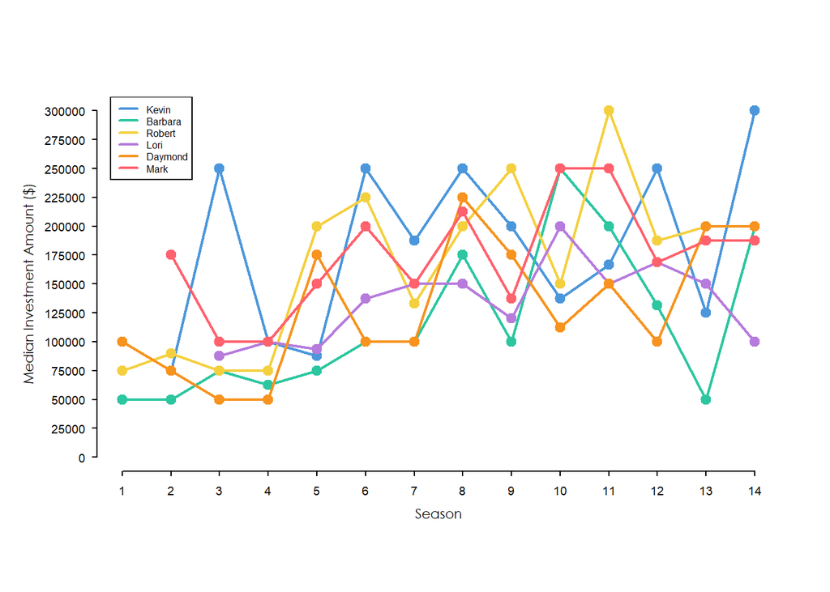

```r
colors <- c("#4C97DB", "#2CC6A0", "#F4D03F", "#B67BDC", "#F7931E", "#FF616D")
plot(aggregate(kevin[kevin$Kevin.O.Leary.Investment.Amount>0,]$Kevin.O.Leary.Investment.Amount ~ kevin[kevin$Kevin.O.Leary.Investment.Amount>0,]$Season.Number, kevin[kevin$Kevin.O.Leary.Investment.Amount>0,], median), type='o', pch=19, lwd=2, ylim=c(0, 300000), cex.lab=0.8, axes=F, col = colors[1], xlab='', ylab='')
lines(aggregate(barbara[barbara$Barbara.Corcoran.Investment.Amount>0,]$Barbara.Corcoran.Investment.Amount ~ barbara[barbara$Barbara.Corcoran.Investment.Amount>0,]$Season.Number, barbara[barbara$Barbara.Corcoran.Investment.Amount>0,], median), type='o', pch=19, lwd=2, col = colors[2])
lines(aggregate(robert[robert$Robert.Herjavec.Investment.Amount>0,]$Robert.Herjavec.Investment.Amount ~ robert[robert$Robert.Herjavec.Investment.Amount>0,]$Season.Number, robert[robert$Robert.Herjavec.Investment.Amount>0,], median), type='o', pch=19, lwd=2, col = colors[3])
lines(aggregate(lori[lori$Lori.Greiner.Investment.Amount>0,]$Lori.Greiner.Investment.Amount ~ lori[lori$Lori.Greiner.Investment.Amount>0,]$Season.Number, lori[lori$Lori.Greiner.Investment.Amount>0,], median), type='o', pch=19, lwd=2, col = colors[4])
lines(aggregate(daymond[daymond$Daymond.John.Investment.Amount>0,]$Daymond.John.Investment.Amount ~ daymond[daymond$Daymond.John.Investment.Amount>0,]$Season.Number, daymond[daymond$Daymond.John.Investment.Amount>0,], median), type='o', pch=19, lwd=2, col = colors[5])
lines(aggregate(mark[mark$Mark.Cuban.Investment.Amount>0,]$Mark.Cuban.Investment.Amount ~ mark[mark$Mark.Cuban.Investment.Amount>0,]$Season.Number, mark[mark$Mark.Cuban.Investment.Amount>0,], median), type='o', pch=19, lwd=2, col = colors[6])
axis(side = 1, at = 1:14, cex.axis = 0.6, tcl= -0.2, mgp= c(0,0.2,0))
axis(side = 2, at = seq(0, 300000, 25000), cex.axis = 0.6, mgp= c(0,0.5,0), las=2, tcl= -0.2)
mtext('Median Investment Amount ($)', side = 2, line=2.5, cex=0.7, font=14)
mtext("Season", side = 1, line = 1.2, cex=0.7, font=14)
legend("topleft", legend = c('Kevin', 'Barbara', 'Robert', 'Lori', 'Daymond', 'Mark'), col = colors, lty = 1, lwd = 2, cex=.5, inset = c(0.02, 0))
```

Visualization 2: Median investment equity by shark

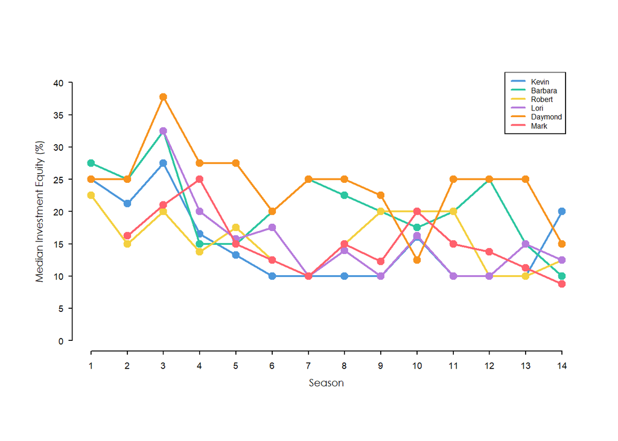

```r
colors <- c("#4C97DB", "#2CC6A0", "#F4D03F", "#B67BDC", "#F7931E", "#FF616D")
plot(aggregate(kevin[kevin$Kevin.O.Leary.Investment.Amount>0,]$Kevin.O.Leary.Investment.Equity ~ kevin[kevin$Kevin.O.Leary.Investment.Amount>0,]$Season.Number, kevin[kevin$Kevin.O.Leary.Investment.Amount>0,], median), type='o', pch=19, lwd=2, xlab='', ylab='', ylim=c(0, 40), cex.lab=0.8, axes=F, col= colors[1])
lines(aggregate(barbara[barbara$Barbara.Corcoran.Investment.Amount>0,]$Barbara.Corcoran.Investment.Equity ~ barbara[barbara$Barbara.Corcoran.Investment.Amount>0,]$Season.Number, barbara[barbara$Barbara.Corcoran.Investment.Amount>0,], median), type='o', pch=19, lwd=2, col=colors[2])
lines(aggregate(robert[robert$Robert.Herjavec.Investment.Amount>0,]$Robert.Herjavec.Investment.Equity ~ robert[robert$Robert.Herjavec.Investment.Amount>0,]$Season.Number, robert[robert$Robert.Herjavec.Investment.Amount>0,], median), type='o', pch=19, lwd=2, col=colors[3])
lines(aggregate(lori[lori$Lori.Greiner.Investment.Amount>0,]$Lori.Greiner.Investment.Equity ~ lori[lori$Lori.Greiner.Investment.Amount>0,]$Season.Number, lori[lori$Lori.Greiner.Investment.Amount>0,], median), type='o', pch=19, lwd=2, col=colors[4])
lines(aggregate(daymond[daymond$Daymond.John.Investment.Amount>0,]$Daymond.John.Investment.Equity ~ daymond[daymond$Daymond.John.Investment.Amount>0,]$Season.Number, daymond[daymond$Daymond.John.Investment.Amount>0,], median), type='o', pch=19, lwd=2, col=colors[5])
lines(aggregate(mark[mark$Mark.Cuban.Investment.Amount>0,]$Mark.Cuban.Investment.Equity ~ mark[mark$Mark.Cuban.Investment.Amount>0,]$Season.Number, mark[mark$Mark.Cuban.Investment.Amount>0,], median), type='o', pch=19, lwd=2, col=colors[6])

axis(side = 1, at = 1:14, cex.axis = 0.6, tcl= -0.2, mgp= c(0,0.2,0))
axis(side = 2, at = seq(0, 40, 5), cex.axis = 0.6, las=2, tcl= -0.2, mgp= c(0,0.5,0))
mtext('Median Investment Equity (%)', side = 2, line=1.5, cex=0.7, font=14)
mtext("Season", side = 1, line = 1.2, cex=0.7, font=14)
legend("topright", legend = c('Kevin', 'Barbara', 'Robert', 'Lori', 'Daymond', 'Mark'), col = colors, lty = 1, lwd = 2, cex=.5, inset = c(0.03, 0))
```

Visualization 3: Shark’s Willingness to make a deal

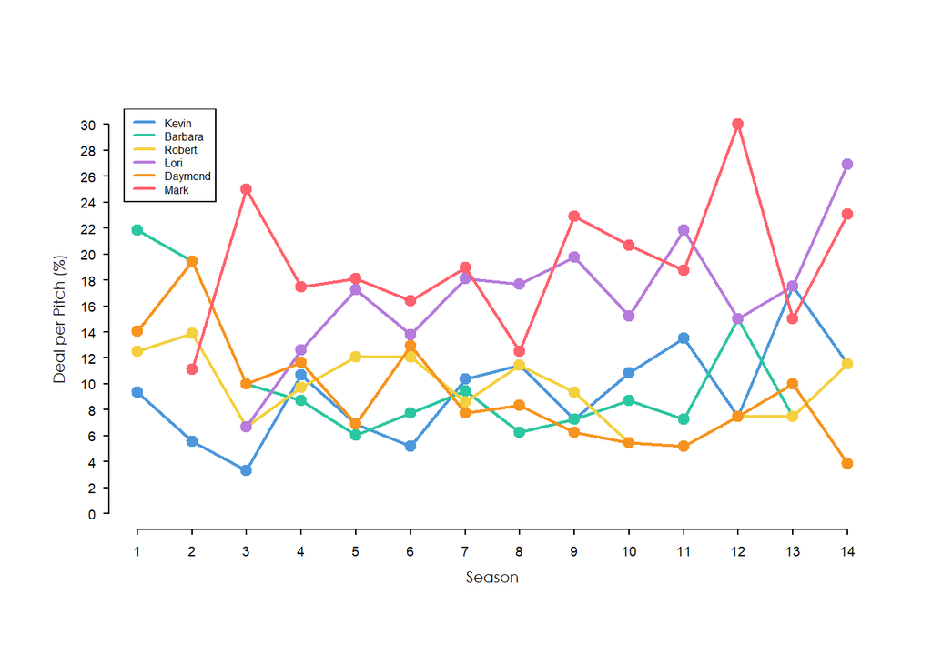

```r
colors <- c("#4C97DB", "#2CC6A0", "#F4D03F", "#B67BDC", "#F7931E", "#FF616D")
pitch_per_season <- tapply(dat$Season.Number, dat$Season.Number, FUN = length)/100

plot(tapply(kevin[kevin$Kevin.O.Leary.Investment.Amount>0,]$Kevin.O.Leary.Investment.Amount, kevin[kevin$Kevin.O.Leary.Investment.Amount>0,]$Season.Number, FUN = length)/pitch_per_season, type='o', pch=19, lwd=2, xlab='', ylab='', ylim=c(0, 30), cex.lab=0.8, axes=F, col=colors[1])
lines(tapply(barbara[barbara$Barbara.Corcoran.Investment.Amount>0,]$Barbara.Corcoran.Investment.Amount, barbara[barbara$Barbara.Corcoran.Investment.Amount>0,]$Season.Number, FUN = length)/pitch_per_season, type='o', pch=19, lwd=2, col=colors[2])
lines(tapply(robert[robert$Robert.Herjavec.Investment.Amount>0,]$Robert.Herjavec.Investment.Amount, robert[robert$Robert.Herjavec.Investment.Amount>0,]$Season.Number, FUN = length)/pitch_per_season, type='o', pch=19, lwd=2, col=colors[3])
lines(c(NA, NA, tapply(lori[lori$Lori.Greiner.Investment.Amount>0,]$Lori.Greiner.Investment.Amount, lori[lori$Lori.Greiner.Investment.Amount>0,]$Season.Number, FUN = length))/pitch_per_season, type='o', pch=19, lwd=2, col=colors[4])
lines(tapply(daymond[daymond$Daymond.John.Investment.Amount>0,]$Daymond.John.Investment.Amount, daymond[daymond$Daymond.John.Investment.Amount>0,]$Season.Number, FUN = length)/pitch_per_season, type='o', pch=19, lwd=2, col=colors[5])
lines(c(NA,tapply(mark[mark$Mark.Cuban.Investment.Amount>0,]$Mark.Cuban.Investment.Amount, mark[mark$Mark.Cuban.Investment.Amount>0,]$Season.Number, FUN = length))/pitch_per_season, type='o', pch=19, lwd=2, col=colors[6])
axis(side = 1, at = 1:14, cex.axis = 0.6, tcl= -0.2, mgp= c(0,0.2,0))
axis(side = 2, at = seq(0, 30, 2), cex.axis = 0.6, las=2, tcl= -0.2, mgp= c(0,0.5,0))
mtext('Deal per Pitch (%)', side = 2, line=1.5, cex=0.7, font=14)
mtext("Season", side = 1, line = 1.2, cex=0.7, font=14)
legend("topleft", legend = c('Kevin', 'Barbara', 'Robert', 'Lori', 'Daymond', 'Mark'), col = colors, lty = 1, lwd = 2, cex=.5, inset = c(0.02, 0))
```

Visualization 4: barplot of median investment, equity, and deal per pitch by shark

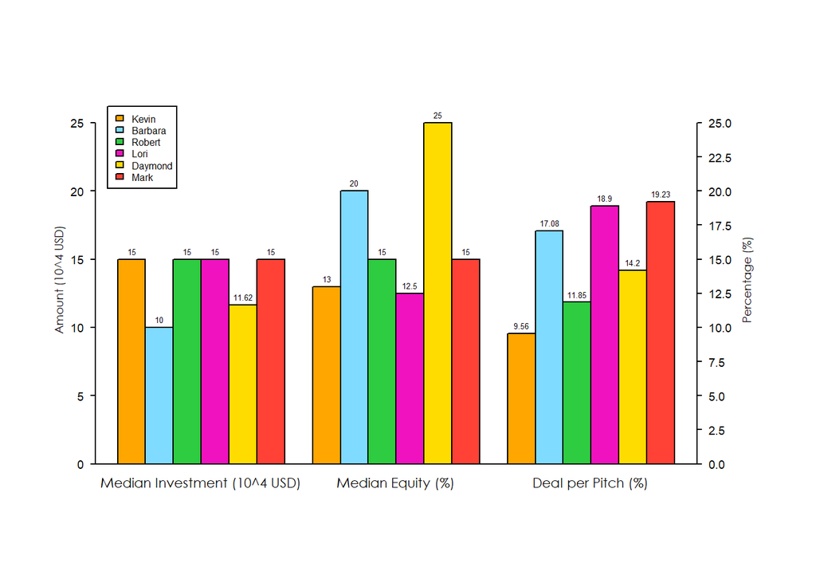

```r
par(mar=c(5, 4, 4, 5)+.1)

colors <- c("#FFA600", "#7FDBFF", "#2ECC40", "#F012BE", "#FFDC00", "#FF4136")

median_investment <- c(median(kevin$Kevin.O.Leary.Investment.Amount[kevin$Kevin.O.Leary.Investment.Amount>0]), median(barbara$Barbara.Corcoran.Investment.Amount[barbara$Barbara.Corcoran.Investment.Amount>0]), median(robert$Robert.Herjavec.Investment.Amount[robert$Robert.Herjavec.Investment.Amount>0]), median(lori$Lori.Greiner.Investment.Amount[lori$Lori.Greiner.Investment.Amount>0]), median(daymond$Daymond.John.Investment.Amount[daymond$Daymond.John.Investment.Amount>0]),median(mark$Mark.Cuban.Investment.Amount[mark$Mark.Cuban.Investment.Amount>0]))

median_equity <- c(median(kevin$Kevin.O.Leary.Investment.Equity[kevin$Kevin.O.Leary.Investment.Equity>0]), median(barbara$Barbara.Corcoran.Investment.Equity[barbara$Barbara.Corcoran.Investment.Equity>0]), median(robert$Robert.Herjavec.Investment.Equity[robert$Robert.Herjavec.Investment.Equity>0]), median(lori$Lori.Greiner.Investment.Equity[lori$Lori.Greiner.Investment.Equity>0]), median(daymond$Daymond.John.Investment.Equity[daymond$Daymond.John.Investment.Equity>0]),median(mark$Mark.Cuban.Investment.Equity[mark$Mark.Cuban.Investment.Equity>0]))

deal_percent <- c(mean(kevin$Kevin.O.Leary.Investment.Amount>0),
                  mean(barbara$Barbara.Corcoran.Investment.Amount>0),
                  mean(robert$Robert.Herjavec.Investment.Amount>0),
                  mean(lori$Lori.Greiner.Investment.Amount>0),
                  mean(daymond$Daymond.John.Investment.Amount>0),
                  mean(mark$Mark.Cuban.Investment.Amount>0))

bp <- barplot(
  height = cbind(median_investment/10000, median_equity*1, deal_percent*100),
  beside = TRUE, ylim = c(0,27), cex.names=.7, font=14,
  col = colors, axes = F)

axis(side = 2, at = seq(0, 27, 5), cex.axis = 0.6, las=2, tcl= -0.2, mgp= c(0,0.5,0))
axis(side = 4, at = seq(0, 27, 2.5), cex.axis = 0.6, las=2, tcl= -0.2, mgp= c(0,0.5,0))
abline(h=0)
mtext('Amount (10^4 USD)', side = 2, line=1.2, cex=0.6, font=14)
mtext('Percentage (%)', side = 4, line=1.5, cex=0.6, font=14)
mtext(text = c("Median Investment (10^4 USD)", "Median Equity (%)", "Deal per Pitch (%)"), side = 1, line = 0.2, at = c(4, 11, 18), cex = 0.7, font=14)

text(x = bp, y = cbind(median_investment/10000, median_equity, deal_percent*100)-.5, labels = round(cbind(median_investment/10000, median_equity, deal_percent*100),2), pos = 3, cex = .4, col = "black")

legend("topleft", legend = c('Kevin', 'Barbara', 'Robert', 'Lori', 'Daymond', 'Mark'), fill = colors, cex=.5, inset = c(0.02, 0.03))
```

```r
# par.default()
```